📘 Repaso teórico | 🏠 Inicio del curso

# Retornos y portafolios manuales — repaso con teoría

## Configuración inicial

```r
if (!require("pacman")) install.packages("pacman")
```

```r
pacman::p_load(tidyverse, EnvStats, ggpubr, psych, quantmod, TTR,
               purrr, PerformanceAnalytics, highcharter, timetk, readxl, scales, htmlwidgets)
options(scipen = 999)
```

# Parte 1 — Carga de precios

**Qué hace**: descarga los precios de cierre ajustados de 5 ETFs desde Yahoo Finance, y muestra tres formas alternativas de cargar los mismos datos (CSV local, Excel local, URL web) — útil cuando no se tiene conexión en vivo o se quiere reproducir un análisis con un snapshot fijo de datos.

**Por qué (teoría)**: en vez de comprar decenas de acciones individuales para diversificar, se usan **ETFs como proxies de clases de activo completas**:

- **SPY** — S&P 500 (renta variable EE.UU., large-cap)
- **EFA** — MSCI EAFE (renta variable internacional desarrollada)
- **IJS** — S&P Small-Cap 600 Value (renta variable EE.UU., small-cap value)
- **EEM** — MSCI Emerging Markets (renta variable mercados emergentes)
- **AGG** — Core U.S. Aggregate Bond (renta fija EE.UU.)

Cinco clases de activo con drivers de riesgo distintos — la base para construir un portafolio diversificado.

```r
symbols <- c("SPY","EFA", "IJS", "EEM", "AGG")

precios <- quantmod::getSymbols(symbols,
                                src = 'yahoo',
                                from = "2010-12-31",
                                periodicity = "daily",
                                auto.assign = TRUE,
                                warnings = FALSE) %>%
    purrr::map(~quantmod::Ad(get(.))) %>%
    purrr::reduce(merge.xts) %>%
    `colnames<-`(symbols)

cat("Descargados", nrow(precios), "días, de", format(zoo::index(precios)[1]),
    "a", format(zoo::index(precios)[nrow(precios)]), "\n")
```

```
## Descargados 3939 días, de 2010-12-31 a 2026-08-31
```

```r
tail(precios)
```

```
##               SPY    EFA    IJS   EEM   AGG
## 2026-08-24 763.47 108.03 137.87 66.11 97.55
## 2026-08-25 765.91 108.81 137.79 67.25 98.01
## 2026-08-26 766.08 108.27 137.93 67.17 97.86
## 2026-08-27 771.10 108.02 138.04 67.61 97.83
## 2026-08-28 769.35     NA     NA    NA    NA
## 2026-08-31 767.05 107.45 136.62 67.02 97.41
```

```r
precios_csv <- read_csv("datos_etf.csv",
                        col_types = cols(date = col_date(format = "%Y-%m-%d"))) %>%
    timetk::tk_xts(date_var = date)
precios_xlsx <- readxl::read_excel("datos_etf.xlsx",
                                   col_types = c("date", rep("numeric", 5))) %>%
    timetk::tk_xts(date_var = date)
url <- "https://raw.githubusercontent.com/salas317/Data/main/TOSF/datos_etf.csv"
precios_url <- read_csv(file = url,
                        col_types = cols(date = col_date(format = "%Y-%m-%d"))) %>%
  timetk::tk_xts(date_var = date)
data.frame(fuente = c("Yahoo (en vivo)", "CSV local", "Excel local", "URL web"),
           filas = c(nrow(precios), nrow(precios_csv), nrow(precios_xlsx), nrow(precios_url)))
```

| fuente | filas |
| --- | --- |
| Yahoo (en vivo) | 3939 |
| CSV local | 3936 |
| Excel local | 3936 |
| URL web | 3936 |

# Parte 2 — Cambio de frecuencia de los precios

**Qué hace**: `xts::to.weekly()`/`to.monthly()`/`to.quarterly()`/`to.yearly()` resamplean la serie diaria, quedándose con el precio de cierre de cada periodo.

**Por qué (teoría)**: la frecuencia del análisis debe coincidir con el horizonte de la decisión. Un portafolio que se rebalancea una vez al mes necesita retornos mensuales, no diarios — usar la frecuencia equivocada distorsiona tanto la volatilidad estimada (los retornos diarios tienen mucho más ruido de microestructura) como la velocidad de rebalanceo implícita en el análisis.

```r
precios_mes <- xts::to.monthly(x = precios, indexAt = "lastof", OHLC = FALSE)
precios_semana <- xts::to.weekly(x = precios, OHLC = FALSE)
precios_trimestre <- xts::to.quarterly(x = precios, indexAt = "lastof", OHLC = FALSE)
precios_anual <- xts::to.yearly(x = precios, OHLC = FALSE)
data.frame(frecuencia = c("Diaria", "Semanal", "Mensual", "Trimestral", "Anual"),
           observaciones = c(nrow(precios), nrow(precios_semana), nrow(precios_mes),
                              nrow(precios_trimestre), nrow(precios_anual)))
```

| frecuencia | observaciones |
| --- | --- |
| Diaria | 3939 |
| Semanal | 819 |
| Mensual | 189 |
| Trimestral | 64 |
| Anual | 17 |

# Parte 3 — Cálculo de los retornos continuos

**Qué hace**: calcula el retorno logarítmico — $\ln(P_t / P_{t-1})$ — a cada una de las 5 frecuencias.

**Por qué (teoría)**: a diferencia del retorno simple, el retorno continuo (logarítmico) es **aditivo en el tiempo**: el retorno de 3 meses es exactamente la suma de los 3 retornos mensuales individuales ($r_{1,3} = r_1 + r_2 + r_3$), lo que simplifica muchísimo la agregación temporal y es la convención estándar en la literatura de riesgo financiero.

```r
# NOTA: se usa diff(log(x)) en vez de TTR::ROC(type="continuous") - con las
# librerías cargadas en este notebook (highcharter, PerformanceAnalytics,
# EnvStats, etc. todas juntas), TTR::ROC() sobre un objeto de to.weekly()/
# to.monthly()/etc. crashea el proceso R sin ningún mensaje de error
# (reproducido incluso con datos sintéticos, ver CLAUDE.md). diff(log(x)) da
# exactamente el mismo resultado matemático y no tiene ese problema.

retornos_diarios <- diff(log(precios)) %>% na.omit()
retornos_semana <- diff(log(precios_semana)) %>% na.omit()
retornos_mes <- diff(log(precios_mes)) %>% na.omit()
retornos_trimestre <- diff(log(precios_trimestre)) %>% na.omit()
retornos_anual <- diff(log(precios_anual)) %>% na.omit()

tail(retornos_mes)
```

```
##                      SPY          EFA          IJS         EEM          AGG
## 2026-03-31 -0.0506404198 -0.081522593 -0.034302667 -0.09708553 -0.018108539
## 2026-04-30  0.0998930143  0.052054907  0.087566926  0.11936662  0.001686565
## 2026-05-31  0.0512877598  0.023948704  0.010770323  0.06956566  0.002931803
## 2026-06-30 -0.0103459012  0.006883112  0.048808601  0.00241083  0.002539224
## 2026-07-31  0.0003481186  0.016232616 -0.005281599 -0.06523078 -0.013050006
## 2026-08-31  0.0264465882  0.017556618  0.004842539  0.04470274  0.003888115
```

# Parte 4 — Visualización de los retornos

**Qué hace**: histogramas, densidad y evolución en el tiempo de los retornos mensuales, comparando las 5 clases de activo.

**Por qué (teoría)**: antes de combinar activos en un portafolio conviene ver cómo se comporta cada uno por separado — qué tan dispersos son sus retornos, si la distribución es simétrica o tiene sesgo, y si se mueven juntos o de forma independiente en el tiempo. Esa intuición visual es la base de por qué diversificar entre clases de activo reduce el riesgo total.

```r
retornos_mes_long <- retornos_mes %>%
    tk_tbl(rename_index = "date") %>%
    gather(key = activo, value = retorno, -date, factor_key = T)
```

```r
# NOTA: EnvStats cargado junto con tidyverse/ggplot2 rompe la dispatch de
# print() sobre objetos ggplot (ggplot2 4.x usa S7; con EnvStats cargado,
# print(p) no dibuja nada y en vez de eso vuelca la estructura interna del
# objeto como texto - ver CLAUDE.md). Se dibuja el grob directamente en vez
# de depender de print().
dibujar <- function(p) {
  grid::grid.newpage()
  grid::grid.draw(ggplot2::ggplotGrob(p))
}
```

## Histograma — todos los activos juntos

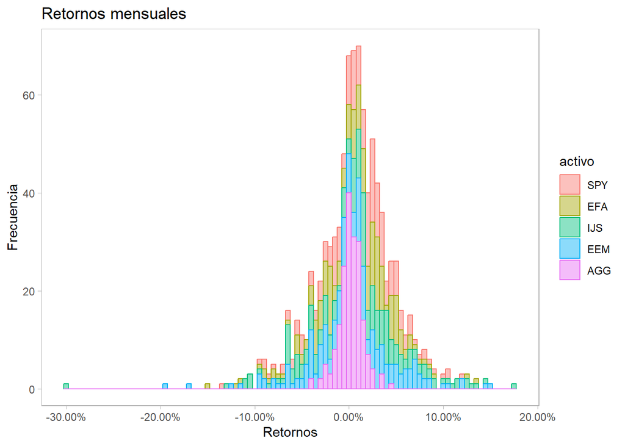

```r
dibujar(retornos_mes_long %>%
    ggplot(mapping = aes(x = retorno, fill = activo, color = activo)) +
    geom_histogram(alpha = 0.45, binwidth = 0.005) +
    labs(title = "Retornos mensuales", x = "Retornos", y = "Frecuencia") +
    theme_light() +
    scale_x_continuous(labels = label_percent(0.01)) +
    theme(panel.grid = element_blank()))
```

## Histograma — separado por activo

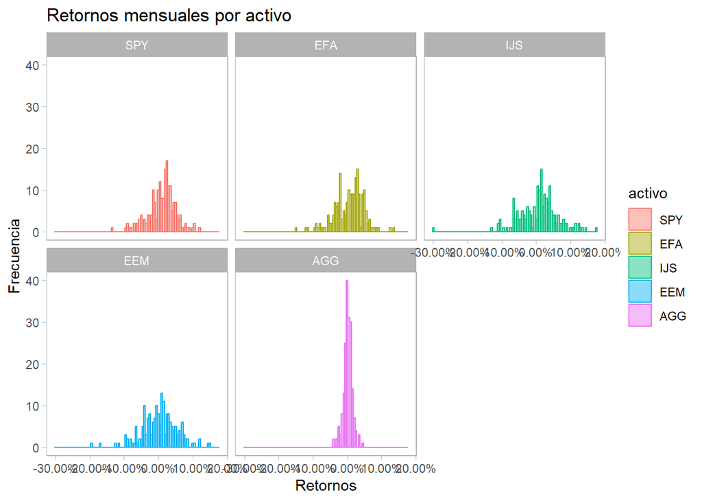

```r
dibujar(retornos_mes_long %>%
    ggplot(mapping = aes(x = retorno, fill = activo, color = activo)) +
    geom_histogram(alpha = 0.45, binwidth = 0.005) +
    labs(title = "Retornos mensuales por activo", x = "Retornos", y = "Frecuencia") +
    theme_light() +
    scale_x_continuous(labels = label_percent(0.01)) +
    facet_wrap(~activo) +
    theme(panel.grid = element_blank()))
```

## Densidad de los retornos

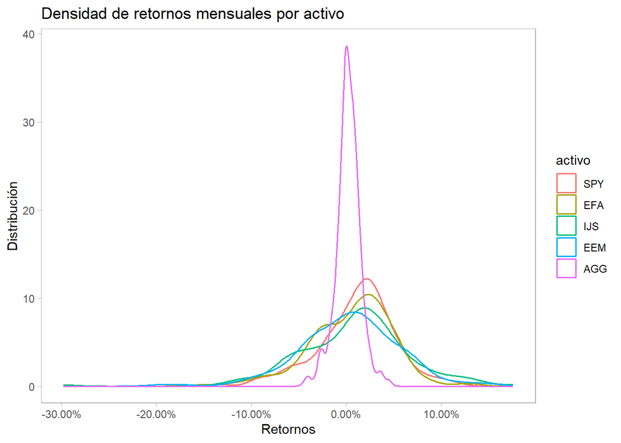

```r
dibujar(retornos_mes_long %>%
    ggplot(mapping = aes(x = retorno, color = activo)) +
    geom_density(alpha = 1, linewidth = 0.7) +
    labs(title = "Densidad de retornos mensuales por activo", x = "Retornos", y = "Distribución") +
    theme_light() +
    scale_x_continuous(labels = label_percent(0.01)) +
    theme(panel.grid = element_blank()))
```

## Evolución de los retornos en el tiempo

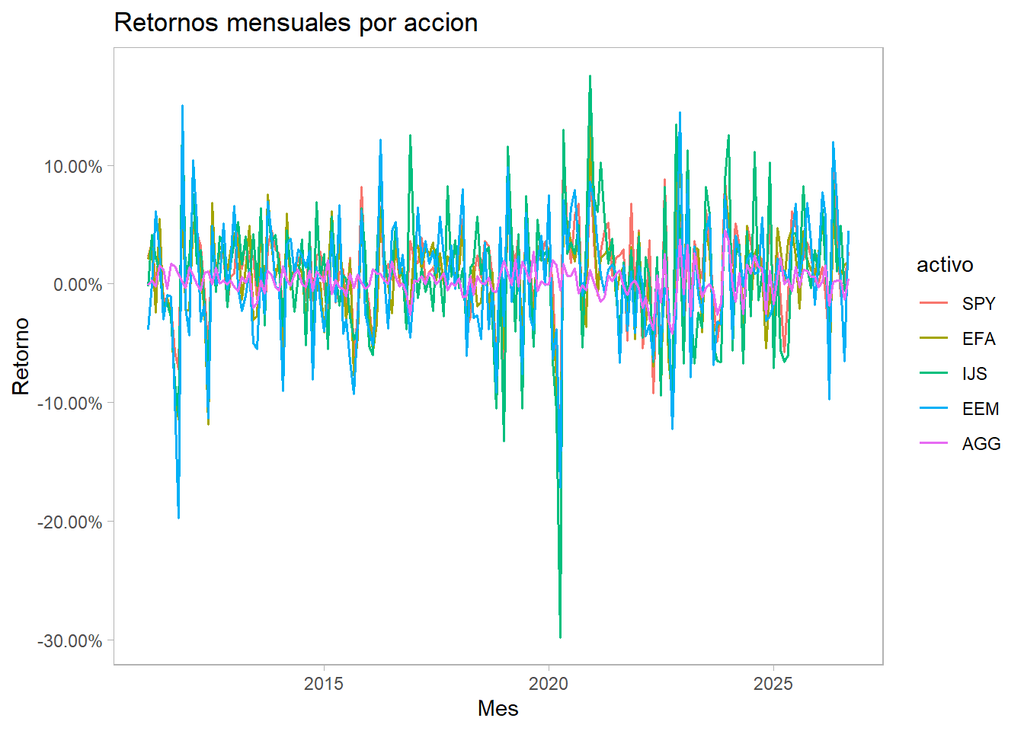

```r
dibujar(retornos_mes_long %>%
    ggplot(mapping = aes(y = retorno, x = date, color = activo)) +
    geom_line(alpha = 1, linewidth = 0.6) +
    labs(title = "Retornos mensuales por accion", x = "Mes", y = "Retorno") +
    theme_light() +
    scale_y_continuous(labels = label_percent(0.01)) +
    theme(panel.grid = element_blank()))
```

## Versión interactiva (highcharter)

**Qué hace**: los mismos retornos mensuales y semanales, pero en un gráfico interactivo (zoom, panorámica, exportar) en vez de una imagen estática — útil para explorar un periodo específico de cerca (por ejemplo, la caída de 2020 o de 2022) sin tener que regenerar el gráfico.

```r
highcharter::highchart(type = "stock") %>%
  hc_title(text = "Retornos mensuales") %>%
  hc_add_series(data = retornos_mes[, symbols[1]]*100, name = symbols[1]) %>%
  hc_add_series(data = retornos_mes[, symbols[2]]*100, name = symbols[2]) %>%
  hc_add_series(data = retornos_mes[, symbols[3]]*100, name = symbols[3]) %>%
  hc_add_series(data = retornos_mes[, symbols[4]]*100, name = symbols[4]) %>%
  hc_add_series(data = retornos_mes[, symbols[5]]*100, name = symbols[5]) %>%
  hc_legend(enabled = T) %>%
  hc_add_theme(hc_theme_gridlight()) %>%
  hc_yAxis(labels = list(format = "{value:.1f}%")) %>%
  hc_exporting(enabled = T) %>%
  hc_navigator(height = 10)
```

[interactive chart not shown]

```r
highcharter::highchart(type = "stock") %>%
  hc_title(text = "Retornos semanales") %>%
  hc_add_series(data = retornos_semana[, symbols[1]]*100, name = symbols[1]) %>%
  hc_add_series(data = retornos_semana[, symbols[2]]*100, name = symbols[2]) %>%
  hc_add_series(data = retornos_semana[, symbols[3]]*100, name = symbols[3]) %>%
  hc_add_series(data = retornos_semana[, symbols[4]]*100, name = symbols[4]) %>%
  hc_add_series(data = retornos_semana[, symbols[5]]*100, name = symbols[5]) %>%
  hc_legend(enabled = T) %>%
  hc_add_theme(hc_theme_gridlight()) %>%
  hc_yAxis(labels = list(format = "{value:.1f}%")) %>%
  hc_exporting(enabled = T) %>%
  hc_navigator(height = 10)
```

[interactive chart not shown]

```r
hc_hist_data <- hist(retornos_mes[,symbols[1]]*100, plot = FALSE)

hchart(hc_hist_data, color = "cornflowerblue") %>%
  hc_title(text = paste(symbols[1], "— Distribución de los retornos")) %>%
  hc_add_theme(hc_theme_gridlight()) %>%
  hc_xAxis(labels = list(format = "{value:.1f}%")) %>%
  hc_exporting(enabled = T) %>%
  hc_legend(enabled = F) %>%
  hc_navigator(height = 10)
```

[interactive chart not shown]

# Parte 5 — Construcción de un portafolio con pesos definidos

**Qué hace**: combina los 5 ETFs con pesos fijos — 25% SPY, 25% EFA, 20% IJS, 20% EEM, 10% AGG — de dos formas distintas, y verifica que ambas dan el mismo resultado.

**Por qué (teoría)**: el retorno de un portafolio con pesos $w_i$ es el promedio ponderado de los retornos de sus componentes, $r_p = \sum_i w_i r_i$ — la forma “a pie” hace ese cálculo explícito; `PerformanceAnalytics::Return.portfolio()` hace lo mismo pero además maneja el **rebalanceo** (volver a los pesos objetivo periódicamente, ya que los pesos reales se desvían solos conforme cada activo sube o baja de precio) — la función que realmente se usa en la práctica, una vez se entiende la mecánica detrás.

```r
w <- c(0.25, 0.25, 0.20, 0.20, 0.10)

## Cálculo "a pie"
accion1_mes <- retornos_mes[,1]
accion2_mes <- retornos_mes[,2]
accion3_mes <- retornos_mes[,3]
accion4_mes <- retornos_mes[,4]
accion5_mes <- retornos_mes[,5]

portfolio_retornos_mes_pie <- w[1]*accion1_mes +
  w[2]*accion2_mes +
  w[3]*accion3_mes +
  w[4]*accion4_mes +
  w[5]*accion5_mes
names(portfolio_retornos_mes_pie) <- "retornos"

## Cálculo con PerformanceAnalytics (con rebalanceo mensual)
portfolio_retornos_mes <- PerformanceAnalytics::Return.portfolio(R = retornos_mes,
                                                                 weights = w,
                                                                 rebalance_on = "months") %>%
  `colnames<-`("retornos")

diferencia_max <- max(abs(portfolio_retornos_mes_pie - portfolio_retornos_mes), na.rm = TRUE)
cat("Diferencia máxima entre ambos métodos:", format(diferencia_max, scientific = TRUE), "\n")
```

```
## Diferencia máxima entre ambos métodos: 2.220446e-16
```

```r
psych::describe(as.numeric(portfolio_retornos_mes))
```

|  | vars | n | mean | sd | median | trimmed | mad | min | max | range | skew | kurtosis | se |
| --- | --- | --- | --- | --- | --- | --- | --- | --- | --- | --- | --- | --- | --- |
| X1 | 1 | 188 | 0.006781466 | 0.03909888 | 0.01219745 | 0.008450302 | 0.03053234 | -0.1657843 | 0.1127272 | 0.2785115 | -0.6471039 | 1.924011 | 0.002851579 |

**Respuesta:** los dos métodos coinciden casi exacto (diferencia del orden de 2.220446e-16, error de punto flotante, no una discrepancia real). El portafolio combinado tiene un retorno mensual promedio de **0.68%** y una desviación estándar de **3.91%** — comparado con los activos individuales de la Parte 4, la combinación diversificada reduce la volatilidad frente a los componentes más riesgosos del grupo, sin sacrificar todo el retorno esperado.

## Versión interactiva del retorno del portafolio

```r
highcharter::highchart(type = "stock") %>%
  hc_title(text = "Retornos mensuales del portafolio") %>%
  hc_add_series(portfolio_retornos_mes$retornos*100,
                name = "Retornos rebalanceados mensualmente",
                color = "cornflowerblue") %>%
  hc_add_theme(hc_theme_gridlight()) %>%
  hc_yAxis(labels = list(format = "{value:.1f}%")) %>%
  hc_legend(enabled = T) %>%
  hc_exporting(enabled = T) %>%
  hc_navigator(height = 10)
```

[interactive chart not shown]